# Employment Case Study

R.M. Palmer

11/30/2019

# Employement Case Study

## DS 6306 - Section 408 - Fall 2019 - Bivin Sadler

```r
knitr::opts_chunk$set(echo = FALSE)
library(tidyverse)
```

# Basic EDA

## Check for NA values

```r
# check for NA values
train_raw %>%
  select_if(function(x) any(is.na(x))) %>%
  summarise_each(funs(sum(is.na(.)))) -> raw_NA
raw_NA
```

```
## data frame with 0 columns and 1 row
```

## Investigate Rate variables

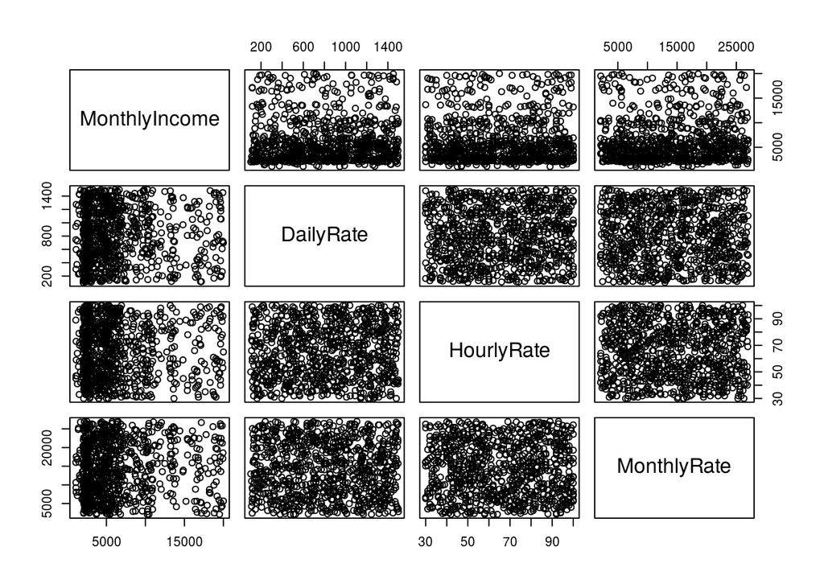

```r
train_raw %>%
  select(MonthlyIncome,DailyRate,HourlyRate,MonthlyRate) %>% pairs()
```

The rate variables do not seem correlated with Monthly Income. We will discard them and stick with only Monthly Income.

## Overall summary

```r
str(train_raw)
```

```
## 'data.frame':    870 obs. of  38 variables:
##  $ ID                      : int  1 2 3 4 5 6 7 8 9 10 ...
##  $ Age                     : int  32 40 35 32 24 27 41 37 34 34 ...
##  $ Attrition               : Factor w/ 2 levels "No","Yes": 1 1 1 1 1 1 1 1 1 1 ...
##  $ BusinessTravel          : Factor w/ 3 levels "Non-Travel","Travel_Frequently",..: 3 3 2 3 2 2 3 3 3 2 ...
##  $ DailyRate               : int  117 1308 200 801 567 294 1283 309 1333 653 ...
##  $ Department              : Factor w/ 3 levels "Human Resources",..: 3 2 2 3 2 2 2 3 3 2 ...
##  $ DistanceFromHome        : int  13 14 18 1 2 10 5 10 10 10 ...
##  $ Education               : int  4 3 2 4 1 2 5 4 4 4 ...
##  $ EducationField          : Factor w/ 6 levels "Human Resources",..: 2 4 2 3 6 2 4 2 2 6 ...
##  $ EmployeeCount           : int  1 1 1 1 1 1 1 1 1 1 ...
##  $ EmployeeNumber          : int  859 1128 1412 2016 1646 733 1448 1105 1055 1597 ...
##  $ EnvironmentSatisfaction : int  2 3 3 3 1 4 2 4 3 4 ...
##  $ Gender                  : Factor w/ 2 levels "Female","Male": 2 2 2 1 1 2 2 1 1 2 ...
##  $ HourlyRate              : int  73 44 60 48 32 32 90 88 87 92 ...
```

[output cut: 24 more lines]

```r
cat ('distance from home')
```

```
## distance from home
```

```r
min(train_raw$DistanceFromHome)
```

```
## [1] 1
```

```r
cat ('Education')
```

```
## Education
```

```r
min(train_raw$Education)
```

```
## [1] 1
```

```r
cat ('EnvironmentSatisfaction')
```

```
## EnvironmentSatisfaction
```

```r
min(train_raw$EnvironmentSatisfaction)
```

```
## [1] 1
```

```r
cat ('JobInvolvement')
```

```
## JobInvolvement
```

```r
min(train_raw$JobInvolvement)
```

```
## [1] 1
```

```r
cat ('JobLevel')
```

```
## JobLevel
```

```r
min(train_raw$JobLevel)
```

```
## [1] 1
```

```r
cat ('JobSatisfaction')
```

```
## JobSatisfaction
```

```r
min(train_raw$JobSatisfaction)
```

```
## [1] 1
```

```r
cat ('NumCompaniesWorked')
```

```
## NumCompaniesWorked
```

```r
min(train_raw$NumCompaniesWorked)
```

```
## [1] 0
```

```r
cat ('PercentSalaryHike')
```

```
## PercentSalaryHike
```

```r
min(train_raw$PercentSalaryHike)
```

```
## [1] 11
```

```r
cat ('PerformanceRating')
```

```
## PerformanceRating
```

```r
min(train_raw$PerformanceRating)
```

```
## [1] 3
```

```r
cat ('RelationshipSatisfaction')
```

```
## RelationshipSatisfaction
```

```r
min(train_raw$RelationshipSatisfaction)
```

```
## [1] 1
```

```r
cat ('StockOptionLevel')
```

```
## StockOptionLevel
```

```r
min(train_raw$StockOptionLevel)
```

```
## [1] 0
```

```r
cat ('TotalWorkingYears')
```

```
## TotalWorkingYears
```

```r
min(train_raw$TotalWorkingYears)
```

```
## [1] 0
```

```r
cat ('TrainingTimesLastYear')
```

```
## TrainingTimesLastYear
```

```r
min(train_raw$TrainingTimesLastYear)
```

```
## [1] 0
```

```r
cat ('WorkLifeBalance')
```

```
## WorkLifeBalance
```

```r
min(train_raw$WorkLifeBalance)
```

```
## [1] 1
```

```r
cat ('YearsAtCompany')
```

```
## YearsAtCompany
```

```r
min(train_raw$YearsAtCompany)
```

```
## [1] 0
```

```r
cat ('YearsInCurrentRole')
```

```
## YearsInCurrentRole
```

```r
min(train_raw$YearsInCurrentRole)
```

```
## [1] 0
```

```r
cat ('YearsSinceLastPromotion')
```

```
## YearsSinceLastPromotion
```

```r
min(train_raw$YearsSinceLastPromotion)
```

```
## [1] 0
```

```r
cat ('YearsWithCurrManager')
```

```
## YearsWithCurrManager
```

```r
min(train_raw$YearsWithCurrManager)
```

```
## [1] 0
```

No variables are negative. When applying log transform, we will add 1 to NumCompaiesWorked, StockOptionLevel, TotalWorkingYears, TrainingTimesLastYear, YearsAtCompany, YearsInCurrentRole, YearsSinceLastPromotion, and YearsWithCurrManager.

# EDA to consider data tranformations

## Make histogram and QQ plot of each numeric variable with log and sqrt tranformations

### Note that when the minimum value of a variable is 0, add 1 to make enable log transform

```r
myqc <- function(varname,zb=0)
{
  index <- which(colnames(train_raw)==varname)
  nbins <- 21
  one_col <- train_raw %>% dplyr::select(index)
  colnames(one_col)  <- c('x')
  p1 <- one_col %>% ggplot(aes(x=x)) + geom_histogram(bins=nbins) + ggtitle(varname)
  p2 <- one_col %>% ggplot(aes(sample=x)) + stat_qq() + ggtitle(varname)
  p3 <- one_col %>% mutate(new_value = log(x+zb)) %>%
    ggplot(aes(x=new_value)) + geom_histogram(bins=nbins) + ggtitle(paste('log',varname))
  p4 <- one_col %>% mutate(new_value = log(x+zb)) %>%
    ggplot(aes(sample=new_value)) + stat_qq() + ggtitle(paste('log',varname))
  p5 <- one_col %>% mutate(new_value = sqrt(x+zb)) %>%
    ggplot(aes(x=new_value)) + geom_histogram(bins=nbins) + ggtitle(paste('sqrt',varname))
  p6 <- one_col %>% mutate(new_value = sqrt(x+zb)) %>%
    ggplot(aes(sample=new_value)) + stat_qq() + ggtitle(paste('sqrt',varname))
  grid.arrange(p1,p2,p3,p4,p5,p6,nrow=3)
}
```

```r
gc()
```

```
##           used (Mb) gc trigger (Mb) max used (Mb)
## Ncells  842150 45.0    1652405 88.3  1187691 63.5
## Vcells 1475595 11.3    8388608 64.0  2207217 16.9
```

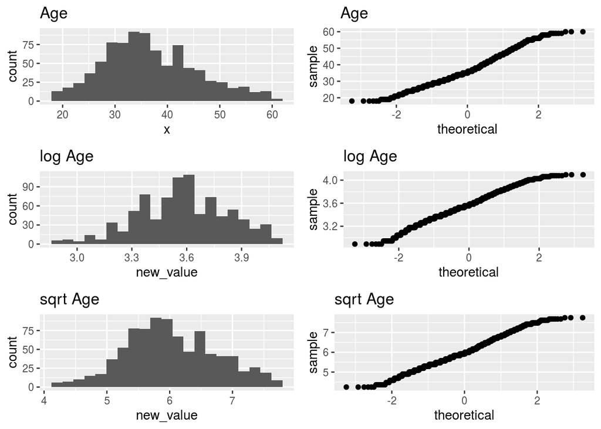

```r
myqc('Age')
```

```r
gc()
```

```
##           used (Mb) gc trigger  (Mb) max used (Mb)
## Ncells 1091572 58.3    2022886 108.1  1652405 88.3
## Vcells 2020588 15.5    8388608  64.0  2792364 21.4
```

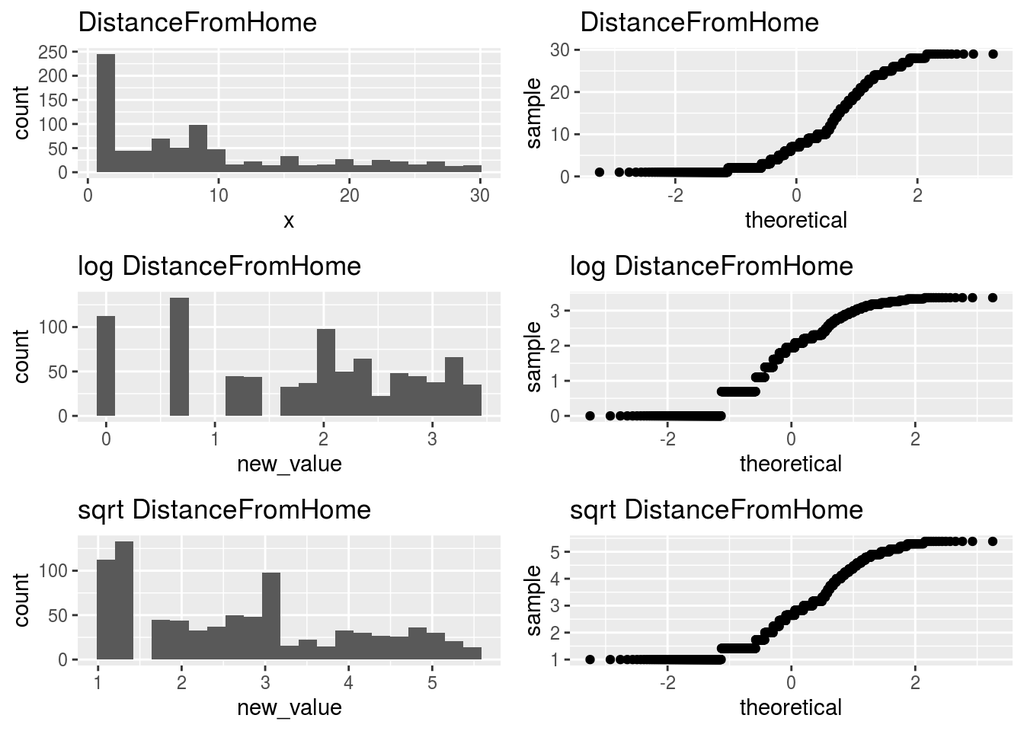

```r
myqc('DistanceFromHome')
```

```r
gc()
```

```
##           used (Mb) gc trigger  (Mb) max used  (Mb)
## Ncells 1245627 66.6    2022886 108.1  2022886 108.1
## Vcells 2362327 18.1    8388608  64.0  2845763  21.8
```

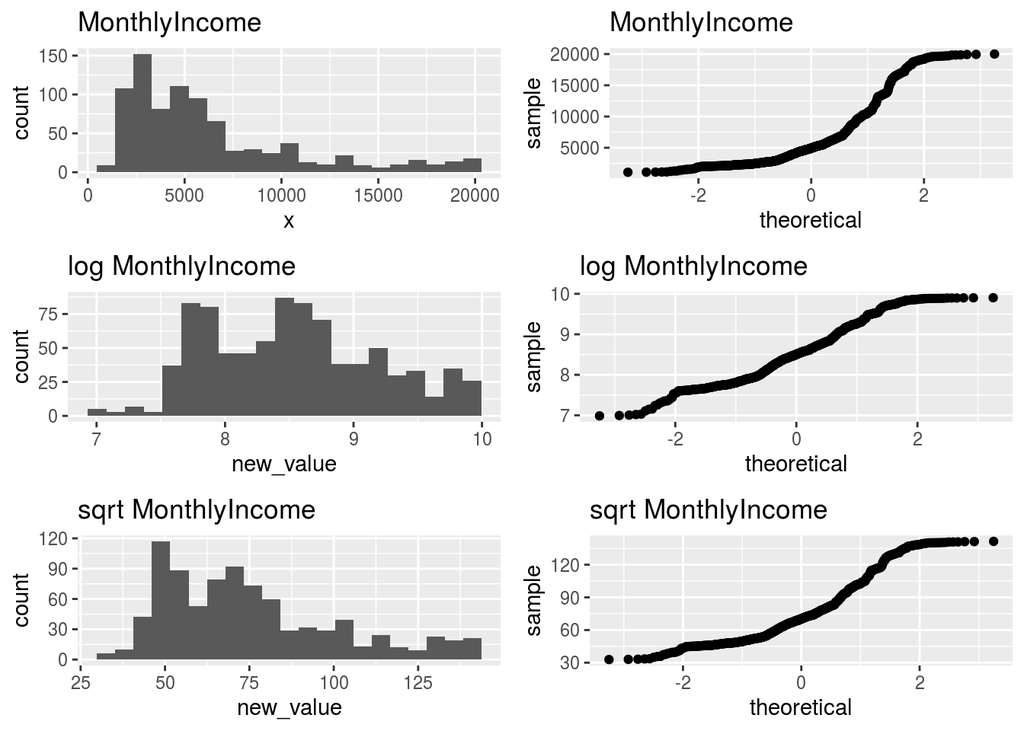

```r
myqc('MonthlyIncome')
```

```r
gc()
```

```
##           used (Mb) gc trigger  (Mb) max used  (Mb)
## Ncells 1359345 72.6    2467463 131.8  2022886 108.1
## Vcells 2620055 20.0    8388608  64.0  2980413  22.8
```

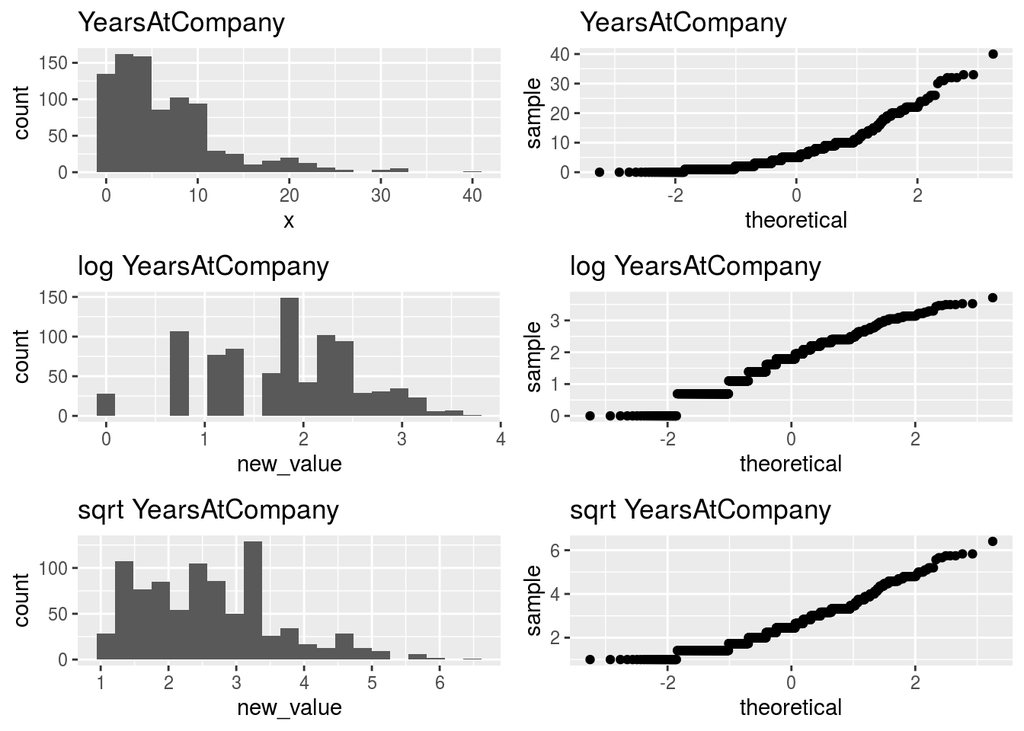

```r
myqc('YearsAtCompany',1)
```

```r
gc()
```

```
##           used (Mb) gc trigger  (Mb) max used  (Mb)
## Ncells 1473032 78.7    2467463 131.8  2467463 131.8
## Vcells 2877920 22.0    8388608  64.0  3557768  27.2
```

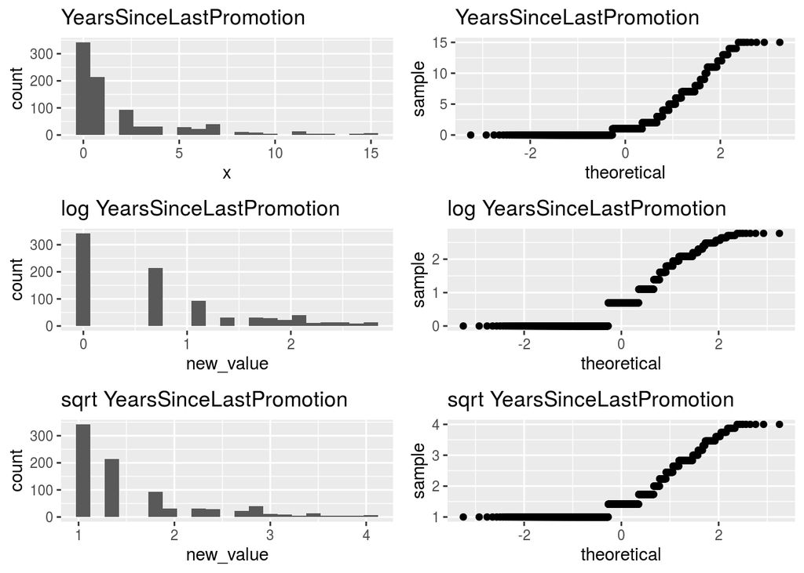

```r
myqc('YearsSinceLastPromotion',1)
```

```r
gc()
```

```
##           used (Mb) gc trigger  (Mb) max used  (Mb)
## Ncells 1586557 84.8    2467463 131.8  2467463 131.8
## Vcells 3134139 24.0    8388608  64.0  3721431  28.4
```

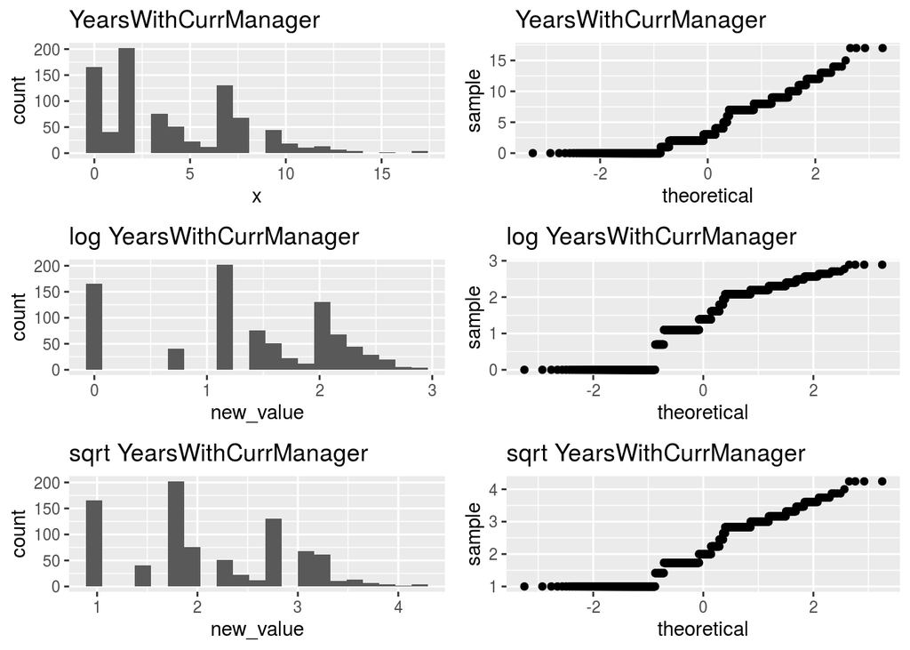

```r
myqc('YearsWithCurrManager',1)
```

```r
gc()
```

```
##           used (Mb) gc trigger  (Mb) max used  (Mb)
## Ncells 1700082 90.8    3000955 160.3  2467463 131.8
## Vcells 3390532 25.9    8388608  64.0  3941404  30.1
```

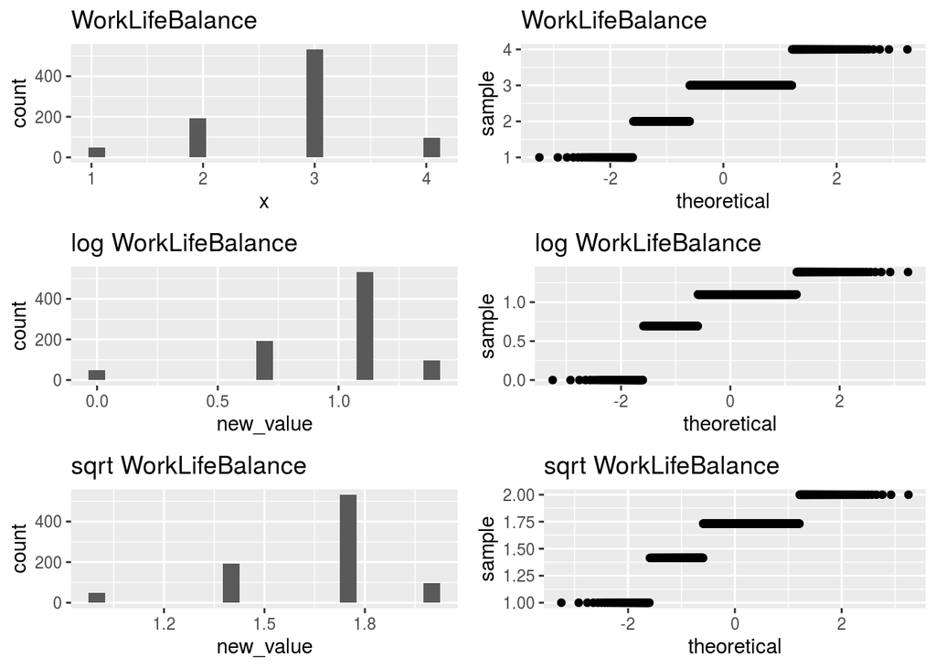

```r
myqc('WorkLifeBalance')
```

```r
gc()
```

```
##           used (Mb) gc trigger  (Mb) max used  (Mb)
## Ncells 1813670 96.9    3000955 160.3  3000955 160.3
## Vcells 3647706 27.9    8388608  64.0  4375753  33.4
```

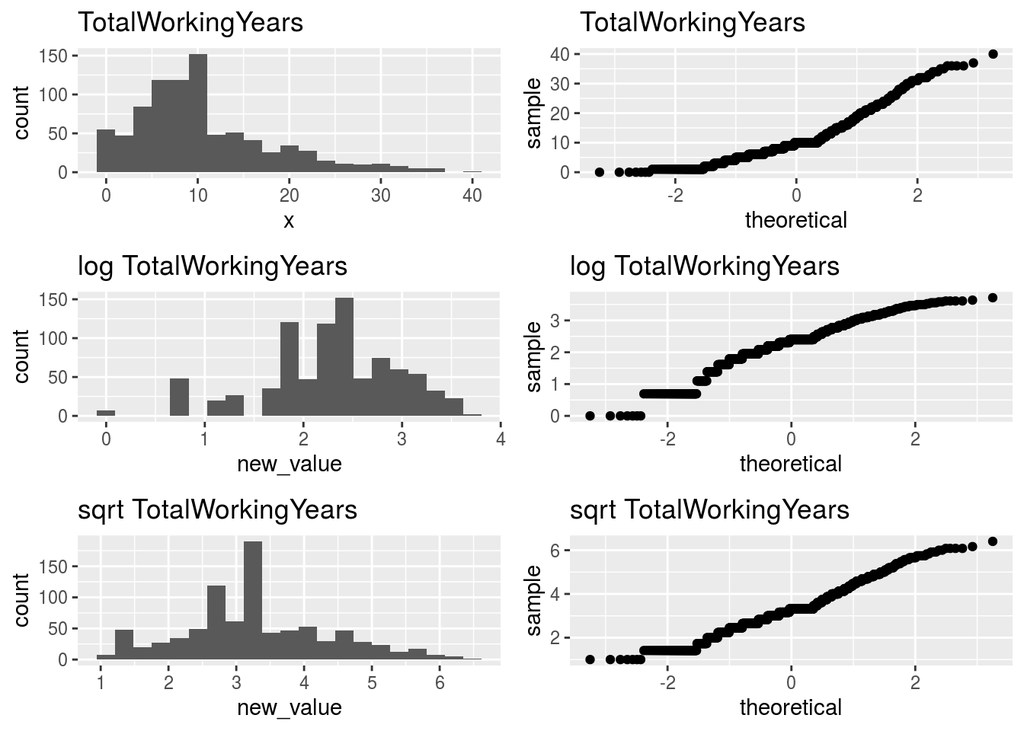

```r
myqc('TotalWorkingYears',1)
```

```r
gc()
```

```
##           used  (Mb) gc trigger  (Mb) max used  (Mb)
## Ncells 1927141 103.0    3000955 160.3  3000955 160.3
## Vcells 3905007  29.8    8388608  64.0  4608772  35.2
```

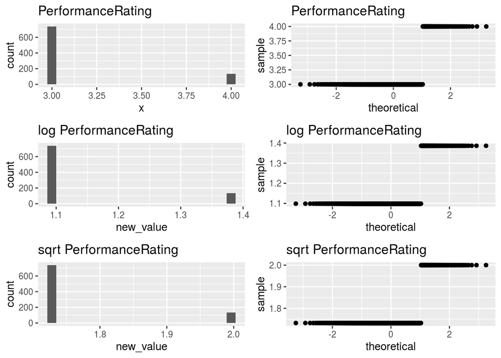

```r
myqc('PerformanceRating')
```

```r
gc()
```

```
##           used  (Mb) gc trigger  (Mb) max used  (Mb)
## Ncells 2040970 109.0    3641146 194.5  3000955 160.3
## Vcells 4162848  31.8    8388608  64.0  4774934  36.5
```

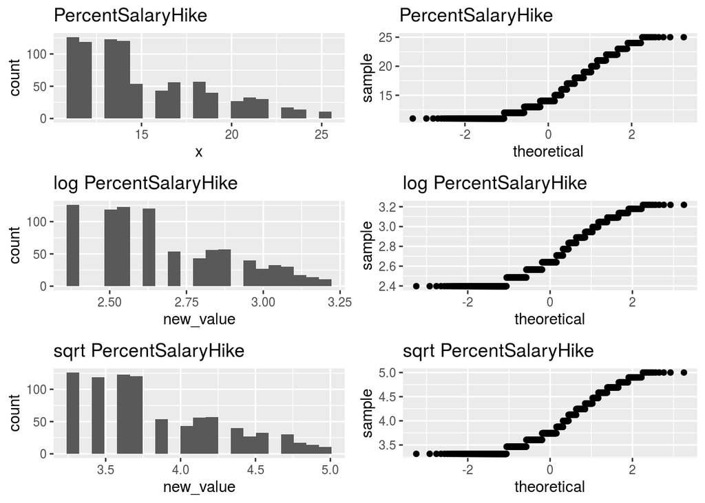

```r
myqc('PercentSalaryHike')
```

```r
gc()
```

```
##           used  (Mb) gc trigger  (Mb) max used  (Mb)
## Ncells 2154340 115.1    3641146 194.5  3641146 194.5
## Vcells 4418678  33.8   10146329  77.5  5323470  40.7
```

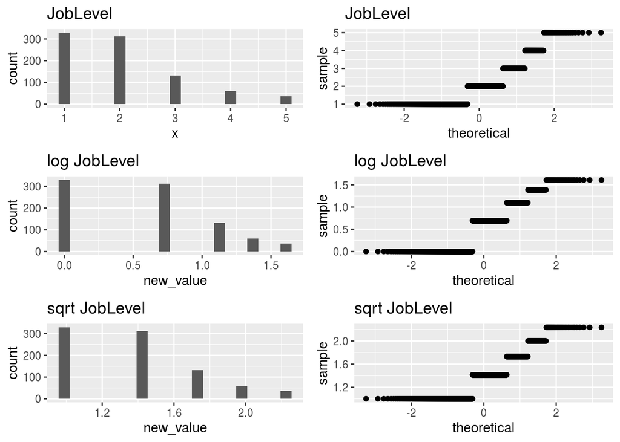

```r
myqc('JobLevel')
```

```r
gc()
```

```
##           used  (Mb) gc trigger  (Mb) max used  (Mb)
## Ncells 2267811 121.2    3641146 194.5  3641146 194.5
## Vcells 4675279  35.7   10146329  77.5  5466884  41.8
```

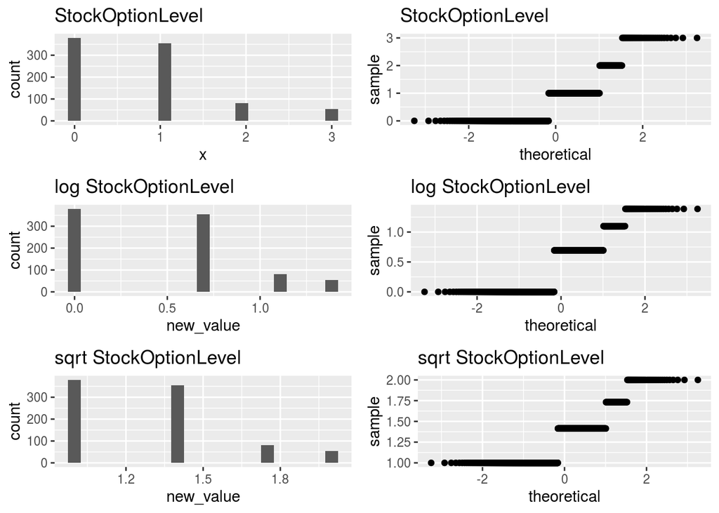

```r
myqc('StockOptionLevel',1)
```

```r
gc()
```

```
##           used  (Mb) gc trigger  (Mb) max used  (Mb)
## Ncells 2381444 127.2    3641146 194.5  3641146 194.5
## Vcells 4932034  37.7   10146329  77.5  5686543  43.4
```

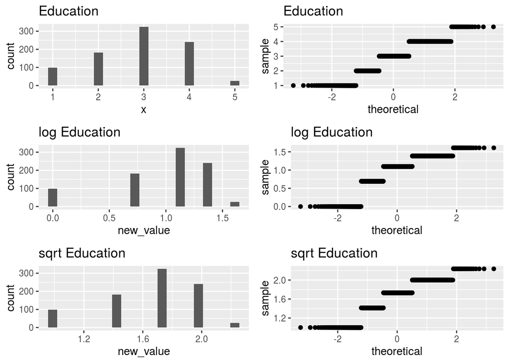

```r
myqc('Education')
```

```r
gc()
```

```
##           used  (Mb) gc trigger  (Mb) max used  (Mb)
## Ncells 2494969 133.3    4409375 235.5  3641146 194.5
## Vcells 5188681  39.6   10146329  77.5  5905698  45.1
```

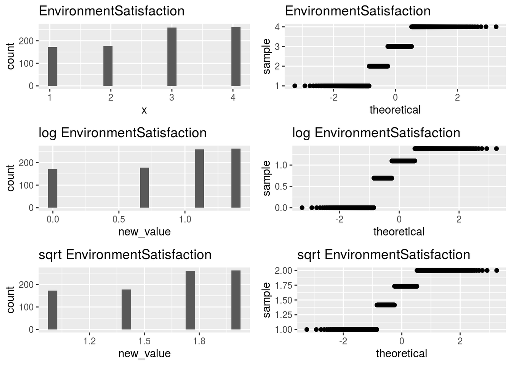

```r
myqc('EnvironmentSatisfaction')
```

```r
gc()
```

```
##           used  (Mb) gc trigger  (Mb) max used  (Mb)
## Ncells 2608467 139.4    4409375 235.5  4409375 235.5
## Vcells 5445321  41.6   12255594  93.6  6625622  50.6
```

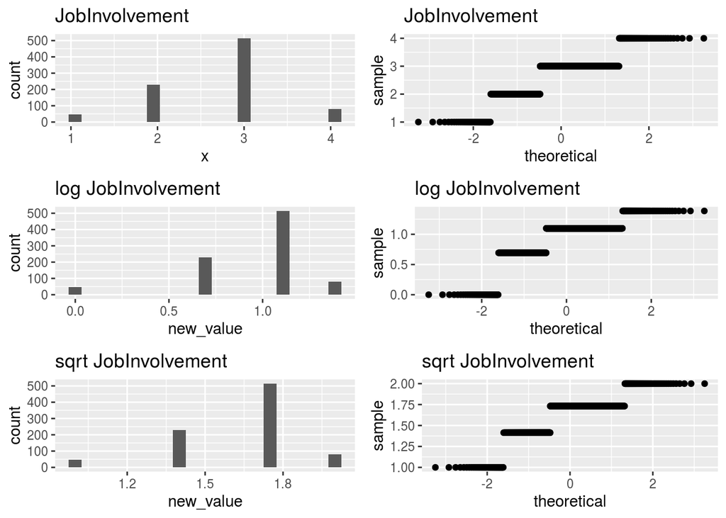

```r
myqc('JobInvolvement')
```

```r
gc()
```

```
##           used  (Mb) gc trigger  (Mb) max used  (Mb)
## Ncells 2722019 145.4    4409375 235.5  4409375 235.5
## Vcells 5702991  43.6   12255594  93.6  6786868  51.8
```

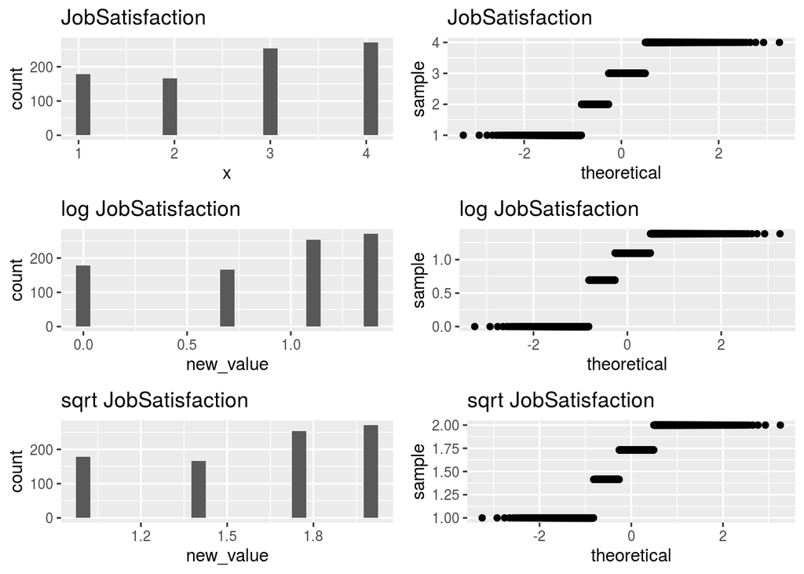

```r
myqc('JobSatisfaction')
```

```r
gc()
```

```
##           used  (Mb) gc trigger  (Mb) max used  (Mb)
## Ncells 2835706 151.5    4409375 235.5  4409375 235.5
## Vcells 5960302  45.5   12255594  93.6  7011848  53.5
```

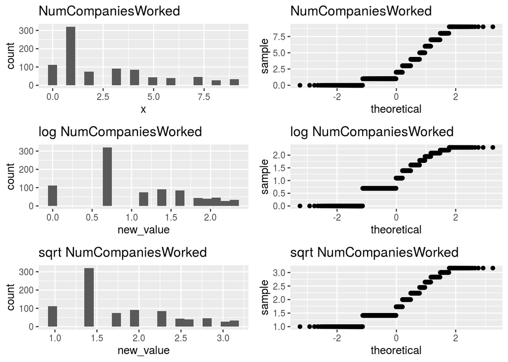

```r
myqc('NumCompaniesWorked',1)
```

```r
gc()
```

```
##           used  (Mb) gc trigger  (Mb) max used  (Mb)
## Ncells 2949152 157.6    4409375 235.5  4409375 235.5
## Vcells 6217408  47.5   12255594  93.6  7113985  54.3
```

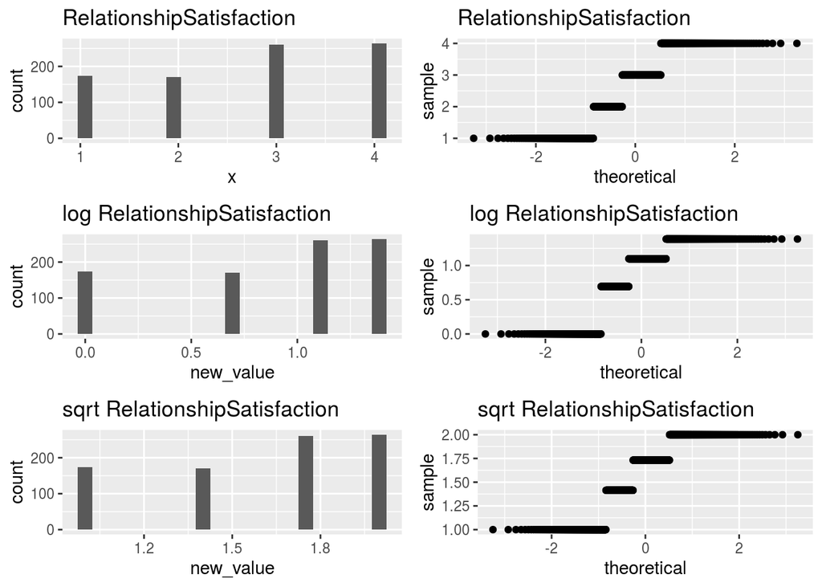

```r
myqc('RelationshipSatisfaction')
```

```r
gc()
```

```
##           used  (Mb) gc trigger  (Mb) max used  (Mb)
## Ncells 3062839 163.6    5331250 284.8  4409375 235.5
## Vcells 6474737  49.4   12255594  93.6  7255680  55.4
```

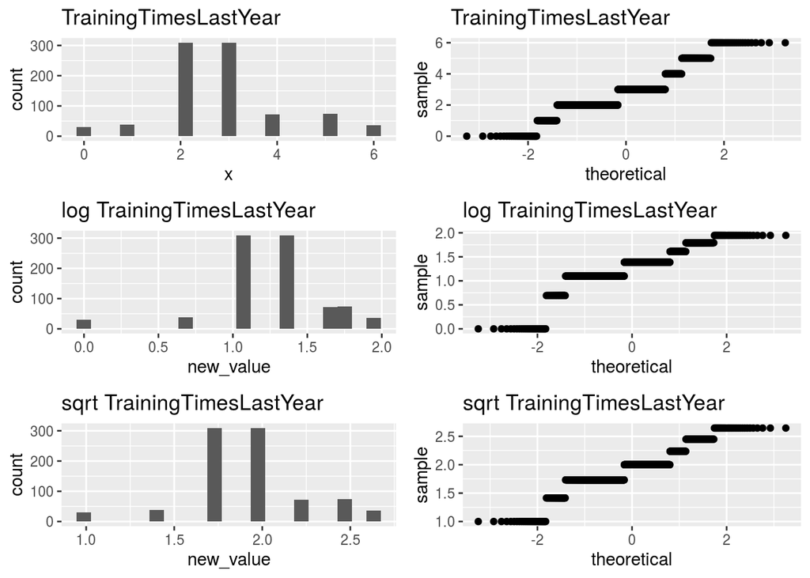

```r
myqc('TrainingTimesLastYear',1)
```

```r
gc()
```

```
##           used  (Mb) gc trigger  (Mb) max used  (Mb)
## Ncells 3176229 169.7    5331250 284.8  5331250 284.8
## Vcells 6730745  51.4   12255594  93.6  8073768  61.6
```

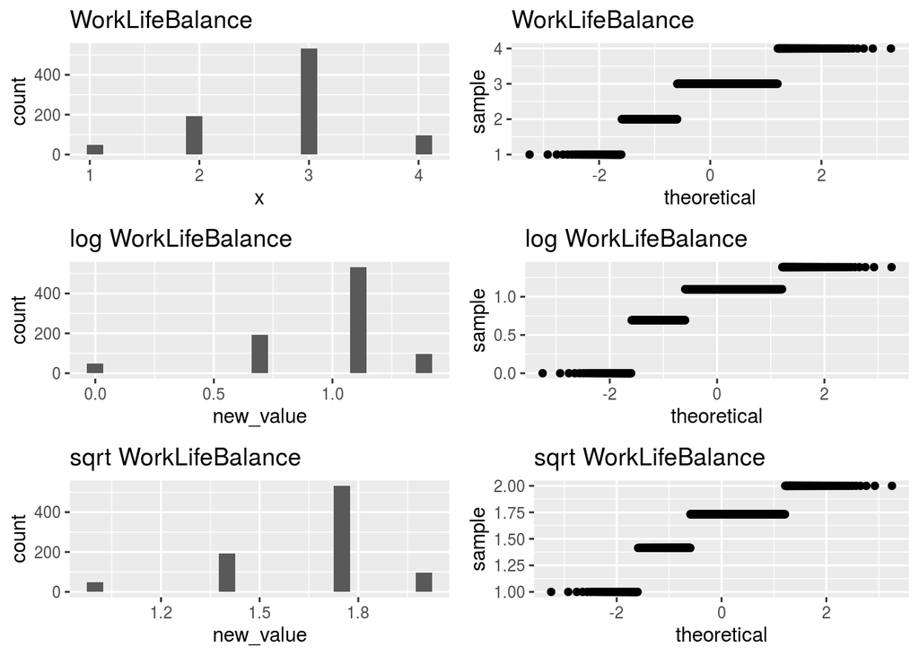

```r
myqc('WorkLifeBalance')
```

```r
gc()
```

```
##           used  (Mb) gc trigger  (Mb) max used  (Mb)
## Ncells 3289860 175.7    5331250 284.8  5331250 284.8
## Vcells 6987492  53.4   14786712 112.9  8231101  62.8
```

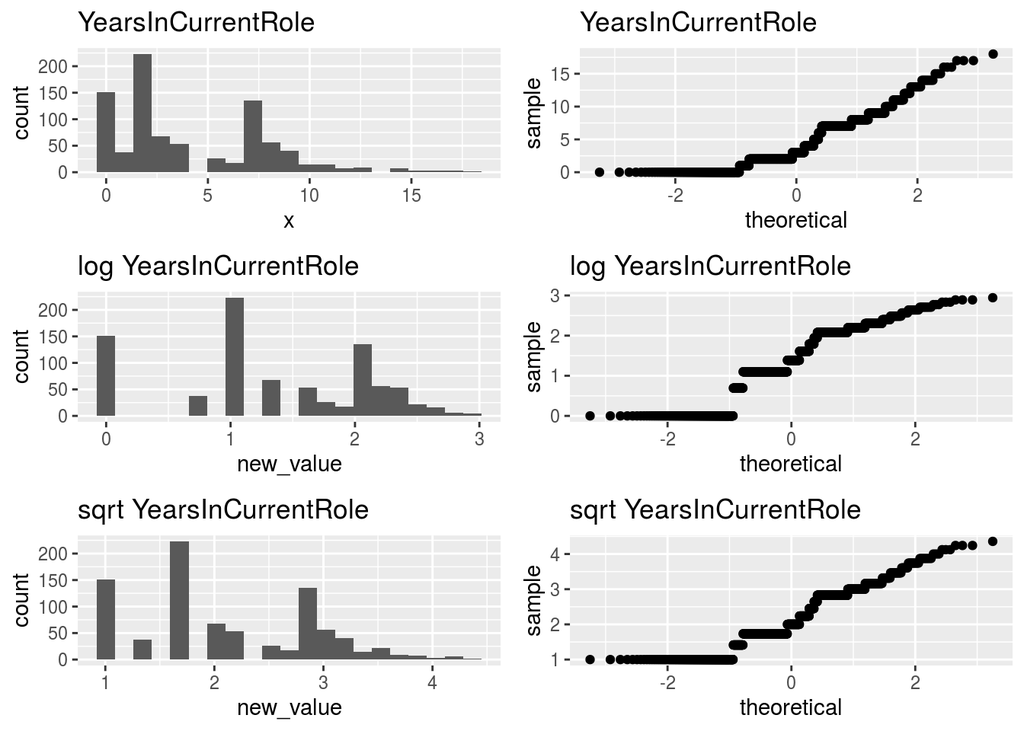

```r
myqc('YearsInCurrentRole',1)
```

```r
gc()
```

```
##           used  (Mb) gc trigger  (Mb) max used  (Mb)
## Ncells 3403331 181.8    5331250 284.8  5331250 284.8
## Vcells 7244649  55.3   14786712 112.9  8451557  64.5
```

```r
knitr::opts_chunk$set(echo = FALSE)
library(tidyverse)
```

# Data Transformation

## Drop unused variables

### these are constant

- Over18
- EmployeeCount
- StandardHours

### the meaning of these is unclear

- DailyRate
- MonthlyRate
- HourlyRate

### These are solely for identification

- EmployeeNumber

## Address non-normality in numeric variables.

### We will apply tranforms as follows:

Age - None  
Distance From Home - Square Root  
Monthly Income - Log  
YearsAtCompany - Log  
YearsSinceLastPromotion - Log  
YearsWithCurrentManager - Log  
WorkLifeBalance - None  
TotalWorkingYears - Squre Root  
PerformanceRating - None  
PercentSalaryHike - None  
JobLevel - None  
StockOptionLevel - None  
Education - None  
EnvironmentSatisfaction - None  
JobInvolvement - None JobSatisfaction - None NumCompaniesWorked - None RelationshipSatisfaction - None TrainingTimesLastYear - None WorkLifeBalance - None YearsInCurrentRole - None

# check for NA values after transform

```
## data frame with 0 columns and 1 row
```

# EDA for predicting attrition

## Histogram of each numeric variable, distinguished by Attrition

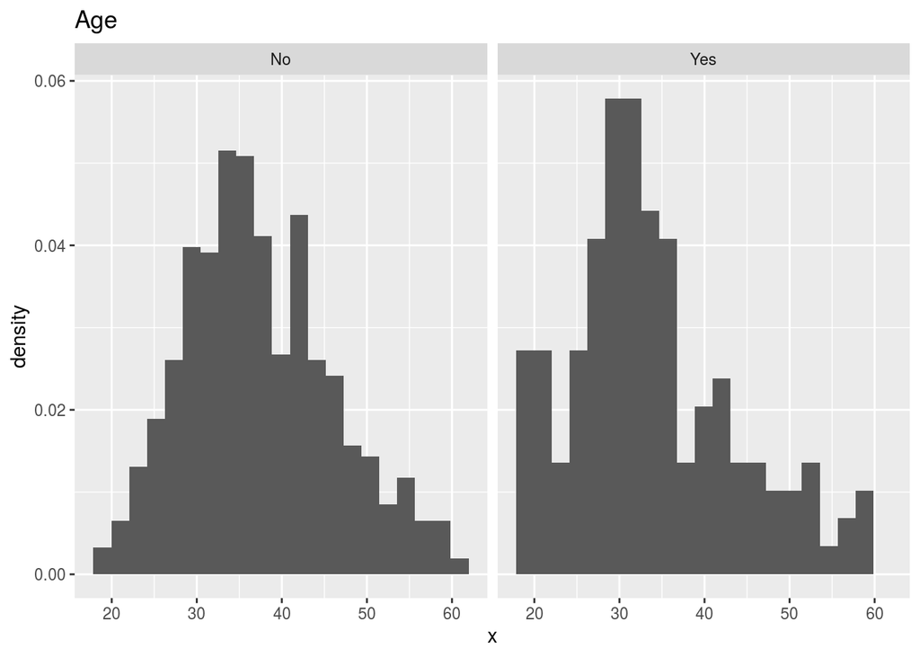

```r
# convenience function
attr_hist <- function(varname)
{
  nbins <- 21
  index_1 <- which(colnames(employee_data)==varname)
  index_2 <- which(colnames(employee_data)=='Attrition')
  two_cols <- employee_data %>% dplyr::select(index_1,index_2)
  colnames(two_cols)  <- c('x','Attrition')
  two_cols %>% ggplot(mapping=aes(x=x,y=..density..)) +
      geom_histogram(bins=nbins) +
      ggtitle(varname) +
      facet_wrap(~Attrition)
}

# histogram of each of the numeric predictors, separated by Attrition
attr_hist('Age')
```

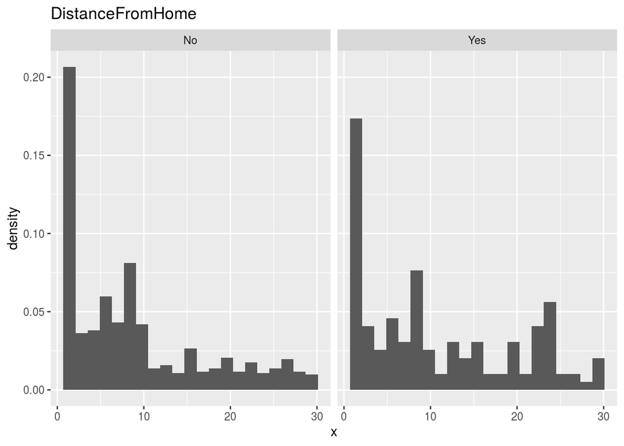

```r
attr_hist('DistanceFromHome')
```

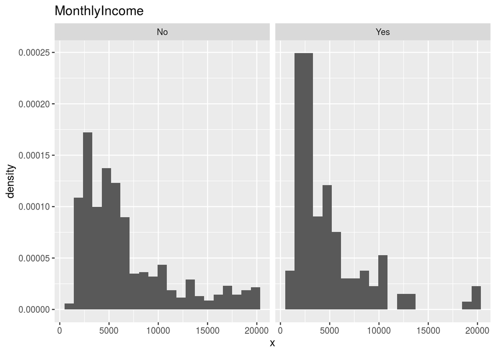

```r
attr_hist('MonthlyIncome')
```

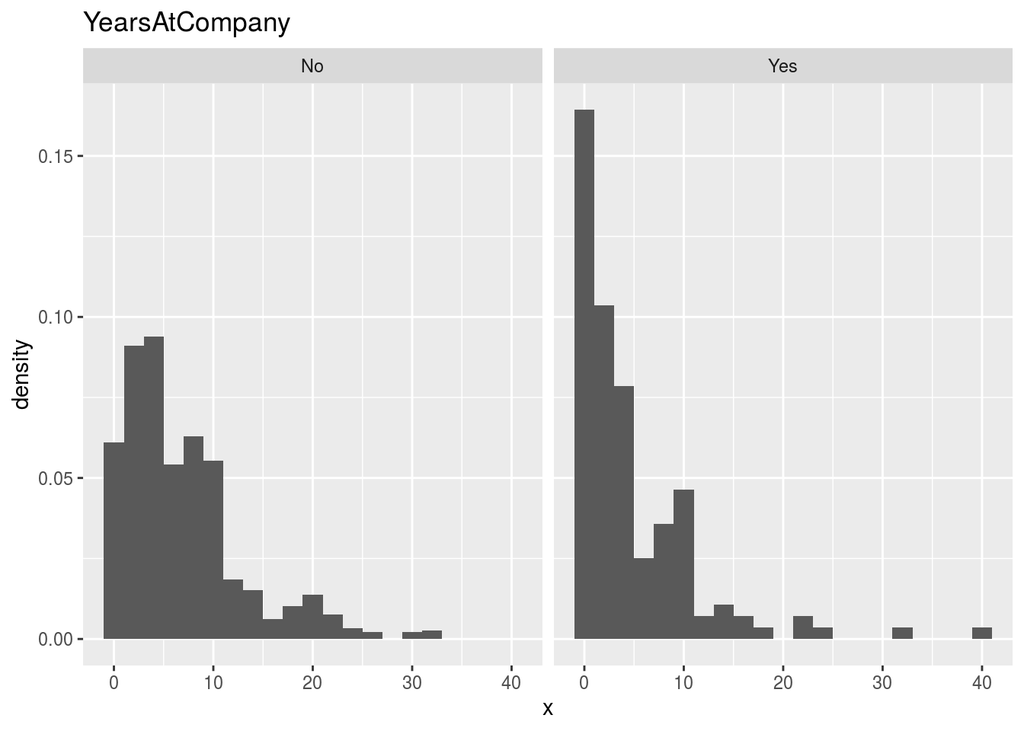

```r
attr_hist('YearsAtCompany')
```

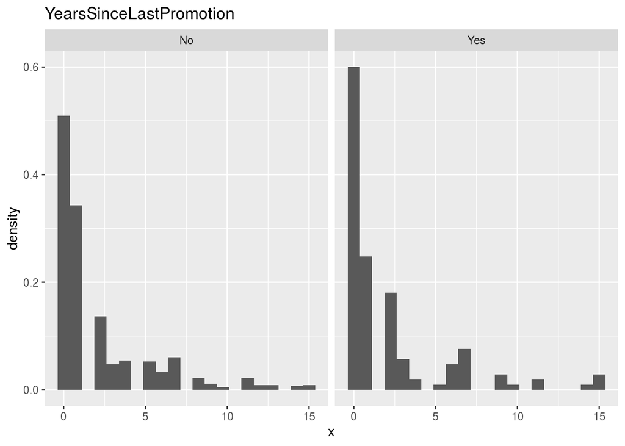

```r
attr_hist('YearsSinceLastPromotion')
```

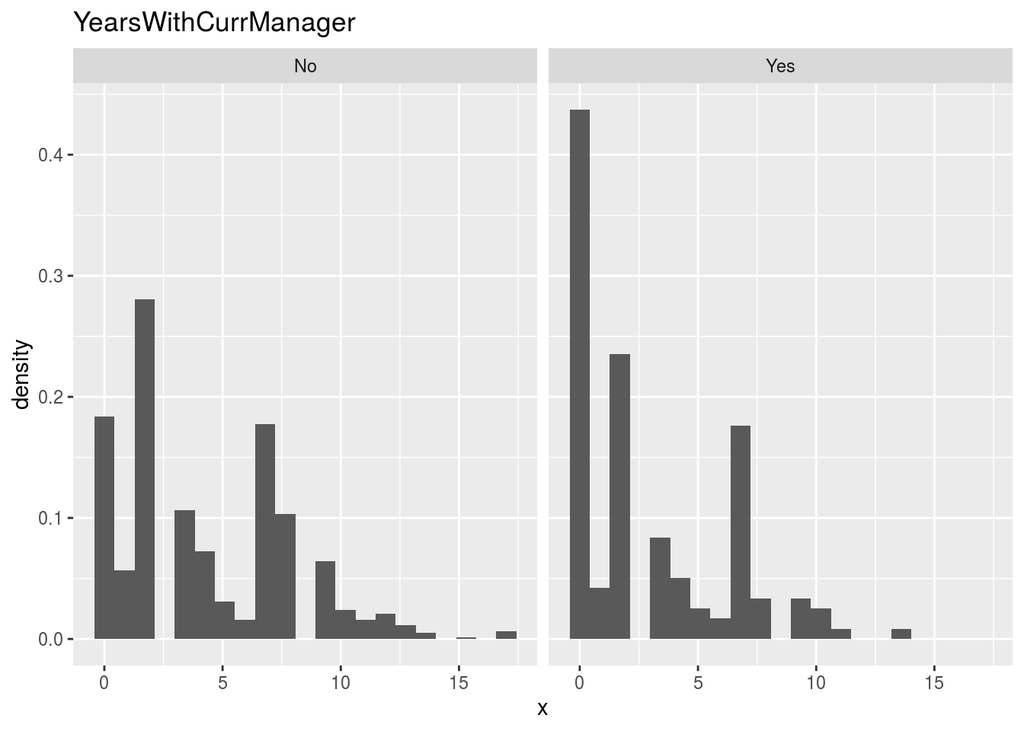

```r
attr_hist('YearsWithCurrManager')
```

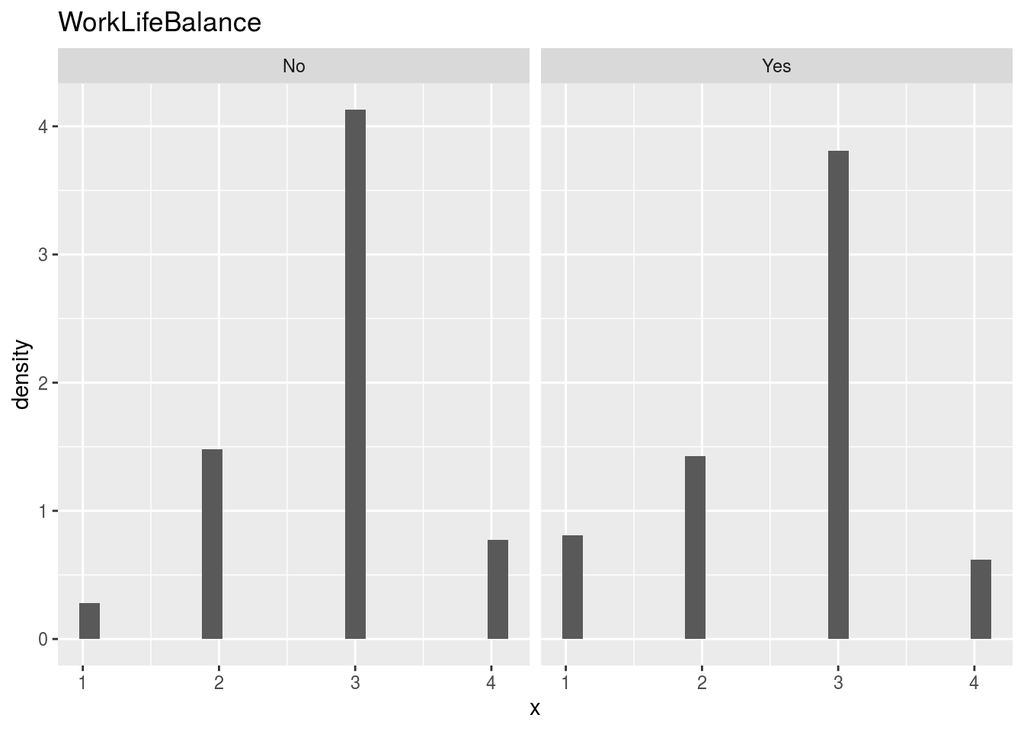

```r
attr_hist('WorkLifeBalance')
```